# STA 202 Project

Siddharth Agrawal

2023-05-06

## summary of data:

```r
data <- read.csv("C:\\Users\\sidda\\Downloads\\socio_eco_disease.csv")
summary(data)
```

```
##     Sr..No.         GP                 SC              VILLAGE
##  Min.   :  1   Length:709         Length:709         Length:709
##  1st Qu.:178   Class :character   Class :character   Class :character
##  Median :355   Mode  :character   Mode  :character   Mode  :character
##  Mean   :355
##  3rd Qu.:532
##  Max.   :709
##    Person_ID      GENDER               AGE          EDUCATION
##  Min.   :  1   Length:709         Min.   :1.000   Min.   :0.0000
##  1st Qu.:178   Class :character   1st Qu.:3.000   1st Qu.:0.0000
##  Median :355   Mode  :character   Median :3.000   Median :1.0000
##  Mean   :355                      Mean   :3.104   Mean   :0.9704
##  3rd Qu.:532                      3rd Qu.:4.000   3rd Qu.:2.0000
##  Max.   :709                      Max.   :4.000   Max.   :3.0000
##    OCCUPATION    MONTHLY.FAMILY.INCOME FAMILY.SIZE        TYPE.OF.HOUSE
##  Min.   :0.000   Min.   :0.0000        Length:709         Min.   :1.000
##  1st Qu.:1.000   1st Qu.:1.0000        Class :character   1st Qu.:1.000
##  Median :1.000   Median :1.0000        Mode  :character   Median :1.000
##  Mean   :1.196   Mean   :0.7856                           Mean   :1.059
##  3rd Qu.:1.000   3rd Qu.:1.0000                           3rd Qu.:1.000
##  Max.   :4.000   Max.   :1.0000                           Max.   :2.000
##  NO.OF.BED.ROOMS   FLOOR.TYPE     ANYBODY.OF.FAMILY.SUFFERED
##  Min.   :1.000   Min.   :0.0000   Min.   : 0.0000
##  1st Qu.:2.000   1st Qu.:1.0000   1st Qu.: 0.0000
##  Median :3.000   Median :1.0000   Median : 0.0000
##  Mean   :2.625   Mean   :0.9676   Mean   : 0.2581
##  3rd Qu.:3.000   3rd Qu.:1.0000   3rd Qu.: 0.0000
##  Max.   :6.000   Max.   :3.0000   Max.   :15.0000
##  Overall.knowledge.about.KA.disease Overall.knowledge.about.vector
##  Min.   :0.0000                     Min.   :0.0000
##  1st Qu.:0.0000                     1st Qu.:0.0000
##  Median :1.0000                     Median :0.0000
##  Mean   :0.6827                     Mean   :0.1989
##  3rd Qu.:1.0000                     3rd Qu.:0.0000
##  Max.   :1.0000                     Max.   :1.0000
##  Overall.attitude Overall.practice
##  Min.   :0.000    Min.   :0.000
##  1st Qu.:2.000    1st Qu.:2.000
##  Median :2.000    Median :2.000
##  Mean   :2.289    Mean   :2.056
##  3rd Qu.:3.000    3rd Qu.:2.000
##  Max.   :3.000    Max.   :3.000
```

```r
library(stargazer)
stargazer(data, omit.summary.stat=c(), summary.stat=c("mean", "sd", "min", "p25", "median", "p75", "max"))
```

```
##
## % Table created by stargazer v.5.2.3 by Marek Hlavac, Social Policy Institute. E-mail: marek.hlavac at gmail.com
## % Date and time: Sun, May 07, 2023 - 23:31:49
## \begin{table}[!htbp] \centering
##   \caption{}
##   \label{}
## \begin{tabular}{@{\extracolsep{5pt}}lccccccc}
## \\[-1.8ex]\hline
## \hline \\[-1.8ex]
## Statistic & \multicolumn{1}{c}{Mean} & \multicolumn{1}{c}{St. Dev.} & \multicolumn{1}{c}{Min} & \multicolumn{1}{c}{Pctl(25)} & \multicolumn{1}{c}{Median} & \multicolumn{1}{c}{Pctl(75)} & \multicolumn{1}{c}{Max} \\
## \hline \\[-1.8ex]
## Sr..No. & 355.000 & 204.815 & 1 & 178 & 355 & 532 & 709 \\
## Person\_ID & 355.000 & 204.815 & 1 & 178 & 355 & 532 & 709 \\
## AGE & 3.104 & 0.792 & 1 & 3 & 3 & 4 & 4 \\
## EDUCATION & 0.970 & 0.898 & 0 & 0 & 1 & 2 & 3 \\
## OCCUPATION & 1.196 & 0.596 & 0 & 1 & 1 & 1 & 4 \\
## MONTHLY.FAMILY.INCOME & 0.786 & 0.411 & 0 & 1 & 1 & 1 & 1 \\
## TYPE.OF.HOUSE & 1.059 & 0.236 & 1 & 1 & 1 & 1 & 2 \\
## NO.OF.BED.ROOMS & 2.625 & 0.703 & 1 & 2 & 3 & 3 & 6 \\
## FLOOR.TYPE & 0.968 & 0.244 & 0 & 1 & 1 & 1 & 3 \\
## ANYBODY.OF.FAMILY.SUFFERED & 0.258 & 0.699 & 0 & 0 & 0 & 0 & 15 \\
## Overall.knowledge.about.KA.disease & 0.683 & 0.466 & 0 & 0 & 1 & 1 & 1 \\
## Overall.knowledge.about.vector & 0.199 & 0.399 & 0 & 0 & 0 & 0 & 1 \\
## Overall.attitude & 2.289 & 0.542 & 0 & 2 & 2 & 3 & 3 \\
## Overall.practice & 2.056 & 0.648 & 0 & 2 & 2 & 2 & 3 \\
## \hline \\[-1.8ex]
## \end{tabular}
## \end{table}
```

## Bar Plots for Level of Education:

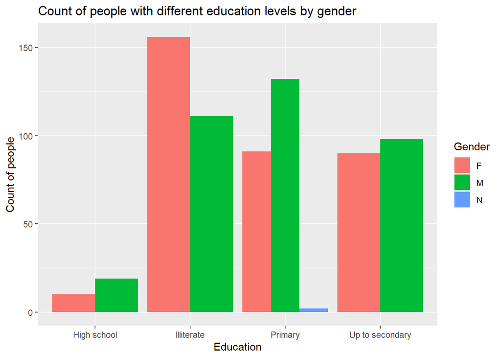

```r
library(ggplot2)
# Read the dataset
data <- read.csv("C:\\Users\\sidda\\Downloads\\socio_eco_disease.csv")

# Subset the data to only include gender and education variables
subset_data <- subset(data, select = c("GENDER", "EDUCATION"))

# Rename the Education variable to make it more clear
subset_data$Education[subset_data$EDUCATION == 0] <- "Illiterate"
subset_data$Education[subset_data$EDUCATION == 1] <- "Primary"
subset_data$Education[subset_data$EDUCATION == 2] <- "Up to secondary"
subset_data$Education[subset_data$EDUCATION == 3] <- "High school"
subset_data$Education[subset_data$EDUCATION == 4] <- "College"

# Group the data by gender and education
grouped_data <- aggregate(subset_data$Education, by=list(Gender=subset_data$GENDER, Education=subset_data$Education), FUN=length)

# Rename the Group.1 variable to Gender
names(grouped_data)[names(grouped_data) == "Group.1"] <- "Gender"

# Draw the bar chart
ggplot(grouped_data, aes(x=Education, y=x, fill=Gender)) +
  geom_bar(stat="identity", position="dodge") +
  labs(x="Education", y="Count of people") +
  ggtitle("Count of people with different education levels by gender")
```

```r
# Sample data
set.seed(123)

# Kruskal-Wallis test
kruskal.test(EDUCATION ~ GENDER, data = subset_data)
```

```
##
##  Kruskal-Wallis rank sum test
##
## data:  EDUCATION by GENDER
## Kruskal-Wallis chi-squared = 9.5305, df = 2, p-value = 0.008521
```

Fig.1 shows bar plot of count of people with different education levels by gender. From the bar plot itself, we may not be able to infer as much if the frequencies of sampled male and female are significantly different. Though this is unlikely to be the case due to the Stratified Random Sampling, it is better to double-check:

```r
data <- read.csv("C:\\Users\\sidda\\Downloads\\socio_eco_disease.csv")

# Get the count of men and women
gender_count <- table(data$GENDER)
gender_count
```

```
##
##   F   M   N
## 347 360   2
```

The counts of male and female in the sampling are close. Therefore, from the bar plot, we can extrapolate that women on an average have a lower literacy level as compared to men. We can see that the number of illiterate women are higher than men. Primary education count in men is higher than women. More men graduated Secondary school than women. More men graduated high school as compared to women.

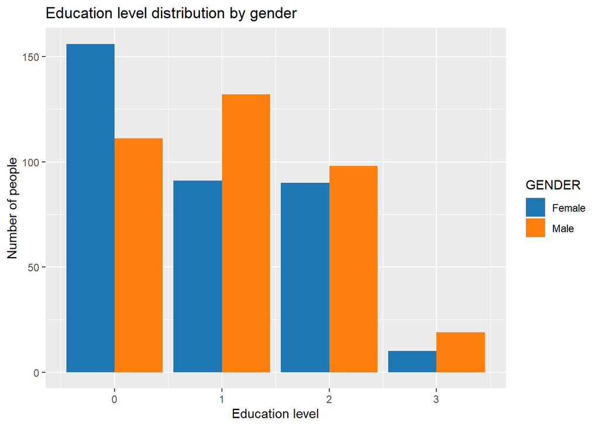

```r
library(ggplot2)

# Filter out the "N" gender
subset_data <- subset(data, GENDER != "N")

# Group the data by gender and education level
edu_counts <- aggregate(subset_data$Person_ID,
                        by = list(GENDER = subset_data$GENDER,
                                  EDUCATION = subset_data$EDUCATION),
                        FUN = length)

# Create the plot
ggplot(edu_counts, aes(x = EDUCATION, y = x, fill = GENDER)) +
  geom_col(position = "dodge") +
  xlab("Education level") +
  ylab("Number of people") +
  ggtitle("Education level distribution by gender") +
  scale_fill_manual(values = c("#1F77B4", "#FF7F0E"),
                    labels = c("Female", "Male"))
```

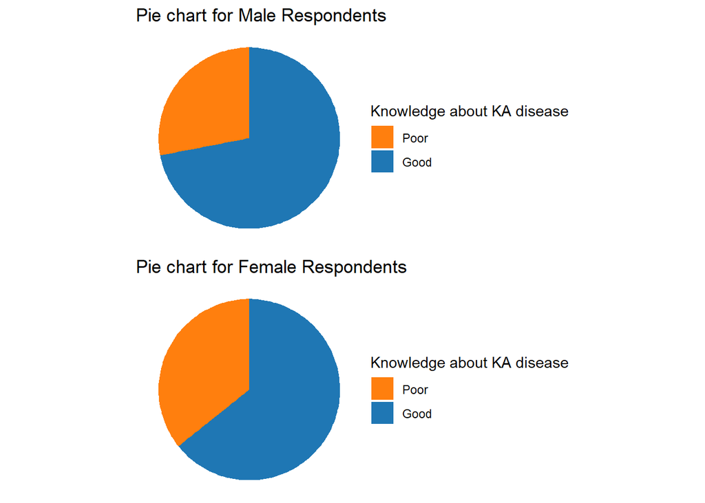

```r
library(ggplot2)
library(dplyr)
# Read the dataset
df <- read.csv("C:\\Users\\sidda\\Downloads\\socio_eco_disease.csv")

# convert GENDER and Overall.knowledge.about.KA.disease to factor
df$GENDER <- as.factor(df$GENDER)
df$Overall.knowledge.about.KA.disease <- as.factor(df$Overall.knowledge.about.KA.disease)

# rename the factor levels
levels(df$GENDER) <- c("Female", "Male", "Not Specified")
levels(df$Overall.knowledge.about.KA.disease) <- c("Poor", "Good")

# create two data frames, one for male and another for female respondents
df_male <- df[df$GENDER == "Male", ]
df_female <- df[df$GENDER == "Female", ]

# create a pie chart for male respondents
p1 <- ggplot(df_male, aes(x = "", fill = Overall.knowledge.about.KA.disease)) +
  geom_bar(width = 1, stat = "count") +
  coord_polar("y", start=0) +
  labs(fill = "Knowledge about KA disease", title = "Pie chart for Male Respondents") +
  scale_fill_manual(values = c("#FF7F0E", "#1F77B4")) +
  theme_void()

# create a pie chart for female respondents
p2 <- ggplot(df_female, aes(x = "", fill = Overall.knowledge.about.KA.disease)) +
  geom_bar(width = 1, stat = "count") +
  coord_polar("y", start=0) +
  labs(fill = "Knowledge about KA disease", title = "Pie chart for Female Respondents") +
  scale_fill_manual(values = c("#FF7F0E", "#1F77B4")) +
  theme_void()

# combine the two pie charts into one window
gridExtra::grid.arrange(ggplotGrob(p1), ggplotGrob(p2), nrow = 2)
```

```r
library(stargazer)
# Read the dataset
data <- read.csv("C:\\Users\\sidda\\Downloads\\socio_eco_disease.csv")
subset_data <- subset(data, GENDER != "N")

data$GENDERF <- ifelse(data$GENDER == "F", 1, 0)
data$GENDERM <- ifelse(data$GENDER == "M", 1, 0)
data$Overall.knowledge.about.KA.disease <- as.factor(data$Overall.knowledge.about.KA.disease)
# Create binary variables for GENDER using one-hot encoding


# Fit logistic regression model with three predictor variables
model <- glm(Overall.knowledge.about.KA.disease ~ GENDERF + 1, data = data, family = binomial(link="logit"))
summary(model)
```

```
##
## Call:
## glm(formula = Overall.knowledge.about.KA.disease ~ GENDERF +
##     1, family = binomial(link = "logit"), data = data)
##
## Deviance Residuals:
##     Min       1Q   Median       3Q      Max
## -1.5978  -1.4346   0.8089   0.9404   0.9404
##
## Coefficients:
##             Estimate Std. Error z value Pr(>|z|)
## (Intercept)   0.9494     0.1172   8.102 5.42e-16 ***
## GENDERF      -0.3625     0.1621  -2.236   0.0253 *
## ---
## Signif. codes:  0 '***' 0.001 '**' 0.01 '*' 0.05 '.' 0.1 ' ' 1
##
## (Dispersion parameter for binomial family taken to be 1)
##
##     Null deviance: 886.04  on 708  degrees of freedom
## Residual deviance: 881.02  on 707  degrees of freedom
## AIC: 885.02
##
## Number of Fisher Scoring iterations: 4
```

```r
stargazer(model)
```

```
##
## % Table created by stargazer v.5.2.3 by Marek Hlavac, Social Policy Institute. E-mail: marek.hlavac at gmail.com
## % Date and time: Sun, May 07, 2023 - 23:31:51
## \begin{table}[!htbp] \centering
##   \caption{}
##   \label{}
## \begin{tabular}{@{\extracolsep{5pt}}lc}
## \\[-1.8ex]\hline
## \hline \\[-1.8ex]
##  & \multicolumn{1}{c}{\textit{Dependent variable:}} \\
## \cline{2-2}
## \\[-1.8ex] & Overall.knowledge.about.KA.disease \\
## \hline \\[-1.8ex]
##  GENDERF & $-$0.363$^{**}$ \\
##   & (0.162) \\
##   & \\
##  Constant & 0.949$^{***}$ \\
##   & (0.117) \\
##   & \\
## \hline \\[-1.8ex]
## Observations & 709 \\
## Log Likelihood & $-$440.510 \\
## Akaike Inf. Crit. & 885.019 \\
## \hline
## \hline \\[-1.8ex]
## \textit{Note:}  & \multicolumn{1}{r}{$^{*}$p$<$0.1; $^{**}$p$<$0.05; $^{***}$p$<$0.01} \\
## \end{tabular}
## \end{table}
```

```r
model <- glm(Overall.knowledge.about.KA.disease ~ GENDERM + 1, data = data, family = binomial(link="logit"))
summary(model)
```

```
##
## Call:
## glm(formula = Overall.knowledge.about.KA.disease ~ GENDERM +
##     1, family = binomial(link = "logit"), data = data)
##
## Deviance Residuals:
##     Min       1Q   Median       3Q      Max
## -1.5943  -1.4386   0.8115   0.9370   0.9370
##
## Coefficients:
##             Estimate Std. Error z value Pr(>|z|)
## (Intercept)   0.5958     0.1118   5.327 9.97e-08 ***
## GENDERM       0.3459     0.1621   2.134   0.0328 *
## ---
## Signif. codes:  0 '***' 0.001 '**' 0.01 '*' 0.05 '.' 0.1 ' ' 1
##
## (Dispersion parameter for binomial family taken to be 1)
##
##     Null deviance: 886.04  on 708  degrees of freedom
## Residual deviance: 881.47  on 707  degrees of freedom
## AIC: 885.47
##
## Number of Fisher Scoring iterations: 4
```

```r
stargazer(model)
```

```
##
## % Table created by stargazer v.5.2.3 by Marek Hlavac, Social Policy Institute. E-mail: marek.hlavac at gmail.com
## % Date and time: Sun, May 07, 2023 - 23:31:51
## \begin{table}[!htbp] \centering
##   \caption{}
##   \label{}
## \begin{tabular}{@{\extracolsep{5pt}}lc}
## \\[-1.8ex]\hline
## \hline \\[-1.8ex]
##  & \multicolumn{1}{c}{\textit{Dependent variable:}} \\
## \cline{2-2}
## \\[-1.8ex] & Overall.knowledge.about.KA.disease \\
## \hline \\[-1.8ex]
##  GENDERM & 0.346$^{**}$ \\
##   & (0.162) \\
##   & \\
##  Constant & 0.596$^{***}$ \\
##   & (0.112) \\
##   & \\
## \hline \\[-1.8ex]
## Observations & 709 \\
## Log Likelihood & $-$440.734 \\
## Akaike Inf. Crit. & 885.469 \\
## \hline
## \hline \\[-1.8ex]
## \textit{Note:}  & \multicolumn{1}{r}{$^{*}$p$<$0.1; $^{**}$p$<$0.05; $^{***}$p$<$0.01} \\
## \end{tabular}
## \end{table}
```

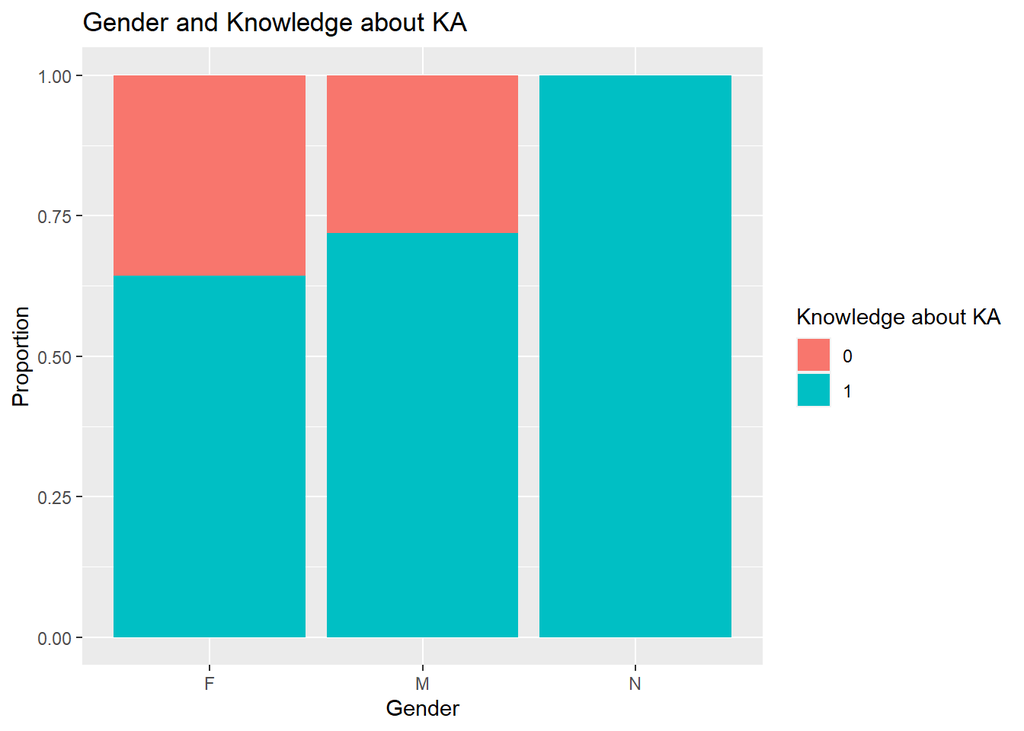

```r
ggplot(data, aes(x = GENDER, fill = Overall.knowledge.about.KA.disease)) +
  geom_bar(position = "fill") +
  labs(x = "Gender", y = "Proportion", fill = "Knowledge about KA") +
  ggtitle("Gender and Knowledge about KA")
```

The logistic regression model was used to fit the association between gender (female) and overall knowledge about KA disease as reported by respondents. The overall knowledge about KA disease was treated as the dependent variable, which was classified as 1 or 0 for good and poor, respectively. Gender was the independent variable. The logistic regression model was applied with a binomial family and logit link function.

The coefficients of the model showed that the intercept (representing the log-odds of the outcome when gender was zero) was estimated to be 0.9494, with a standard error of 0.1172. The estimate for gender (female) was -0.3625, with a standard error of 0.1621. The negative sign for the gender estimate suggested that being female was associated with lower odds of having good knowledge about KA disease.

The z-value for the intercept was 8.102 with a p-value of 5.42e-16, indicating that the intercept was significantly different from zero. The z-value for gender was -2.236 with a p-value of 0.0253, indicating that gender was associated with overall knowledge about KA disease at a statistical significance level of 5%. The Logistic regression thus indicates that the relationship between overall knowledge about KA disease and being female is unlikely to be due to chance error, but rather due to some other effect. One Potential Effect may be the originally discussed differences in education, that are affecting woman negatively in this regard…

The null deviance and residual deviance were 886.04 and 881.02, respectively. The residual deviance represents the goodness of fit of the model, with a lower residual deviance indicating a better fit. The AIC (Akaike Information Criterion) was 885.02, which is a measure of the relative quality of the statistical model for a given set of data. A lower AIC value indicates a better fit of the model.

In conclusion, the logistic regression model showed that gender was a significant predictor of overall knowledge about KA disease, with females having lower odds of good knowledge than males.

The second model is also a logistic regression model that examines the relationship between gender (male) and overall knowledge about KA disease. The variable “Overall.knowledge.about.KA.disease” is the dependent variable, which has two levels (good and poor knowledge), and gender is the independent variable.

The coefficient for the gender variable is 0.3459, indicating that the odds of having good knowledge about KA disease for females is exp(0.3459) times lower than that for males, all else being equal. This coefficient is statistically significant (p = 0.0328), suggesting that gender is a significant predictor of overall knowledge about KA disease.

The deviance residuals indicate that the model fits the data reasonably well. The null deviance, which is the deviance when only the intercept is included in the model, is 886.04, while the residual deviance is 881.47. The AIC value is 885.47, which is a measure of the model’s goodness of fit. The number of Fisher Scoring iterations was 4.

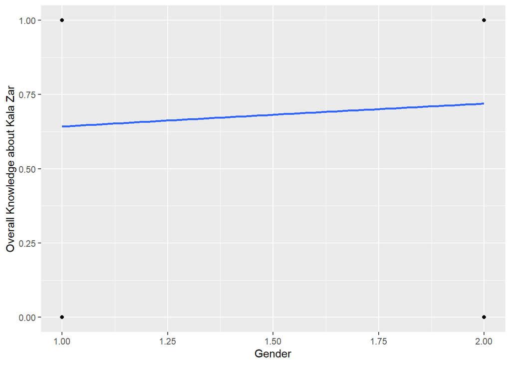

```r
# Read in the data from the CSV file
data <- read.csv("C:\\Users\\sidda\\Downloads\\socio_eco_disease.csv")
data <- subset(data, GENDER != "N")

# Convert the factor variable to numeric
data$GENDER <- as.numeric(factor(data$GENDER))

# Fit a logistic regression model with gender as the predictor and knowledge about Kala Zar as the response
model <- glm(Overall.knowledge.about.KA.disease ~ GENDER, data = data, family = binomial)


# Plot the logistic curve using GGplot
library(ggplot2)

ggplot(data, aes(x = GENDER, y = Overall.knowledge.about.KA.disease)) +
  geom_point() +
  geom_smooth(method = "glm", method.args = list(family = binomial), se = FALSE) +
  xlab("Gender") +
  ylab("Overall Knowledge about Kala Zar")
```

```r
# Read the dataset
data <- read.csv("C:\\Users\\sidda\\Downloads\\socio_eco_disease.csv")

data$Gender <- as.factor(data$GENDER)
data$Overall.knowledge.about.vector <- as.factor(data$Overall.knowledge.about.vector)
data$GENDERF <- ifelse(data$GENDER == "F", 1, 0)
data$GENDERM <- ifelse(data$GENDER == "M", 1, 0)

model <- glm(Overall.knowledge.about.vector ~ GENDERF, data = data, family = binomial)
summary(model)
```

```
##
## Call:
## glm(formula = Overall.knowledge.about.vector ~ GENDERF, family = binomial,
##     data = data)
##
## Deviance Residuals:
##     Min       1Q   Median       3Q      Max
## -0.7084  -0.7084  -0.6238  -0.6238   1.8616
##
## Coefficients:
##             Estimate Std. Error z value Pr(>|z|)
## (Intercept)  -1.5382     0.1378 -11.165   <2e-16 ***
## GENDERF       0.2836     0.1889   1.502    0.133
## ---
## Signif. codes:  0 '***' 0.001 '**' 0.01 '*' 0.05 '.' 0.1 ' ' 1
##
## (Dispersion parameter for binomial family taken to be 1)
##
##     Null deviance: 707.35  on 708  degrees of freedom
## Residual deviance: 705.08  on 707  degrees of freedom
## AIC: 709.08
##
## Number of Fisher Scoring iterations: 4
```

```r
stargazer(model)
```

```
##
## % Table created by stargazer v.5.2.3 by Marek Hlavac, Social Policy Institute. E-mail: marek.hlavac at gmail.com
## % Date and time: Sun, May 07, 2023 - 23:31:53
## \begin{table}[!htbp] \centering
##   \caption{}
##   \label{}
## \begin{tabular}{@{\extracolsep{5pt}}lc}
## \\[-1.8ex]\hline
## \hline \\[-1.8ex]
##  & \multicolumn{1}{c}{\textit{Dependent variable:}} \\
## \cline{2-2}
## \\[-1.8ex] & Overall.knowledge.about.vector \\
## \hline \\[-1.8ex]
##  GENDERF & 0.284 \\
##   & (0.189) \\
##   & \\
##  Constant & $-$1.538$^{***}$ \\
##   & (0.138) \\
##   & \\
## \hline \\[-1.8ex]
## Observations & 709 \\
## Log Likelihood & $-$352.542 \\
## Akaike Inf. Crit. & 709.083 \\
## \hline
## \hline \\[-1.8ex]
## \textit{Note:}  & \multicolumn{1}{r}{$^{*}$p$<$0.1; $^{**}$p$<$0.05; $^{***}$p$<$0.01} \\
## \end{tabular}
## \end{table}
```

```r
model <- glm(Overall.knowledge.about.vector ~ GENDERM, data = data, family = binomial)
summary(model)
```

```
##
## Call:
## glm(formula = Overall.knowledge.about.vector ~ GENDERM, family = binomial,
##     data = data)
##
## Deviance Residuals:
##     Min       1Q   Median       3Q      Max
## -0.7113  -0.7113  -0.6203  -0.6203   1.8671
##
## Coefficients:
##             Estimate Std. Error z value Pr(>|z|)
## (Intercept)  -1.2454     0.1285  -9.692   <2e-16 ***
## GENDERM      -0.3052     0.1891  -1.614    0.107
## ---
## Signif. codes:  0 '***' 0.001 '**' 0.01 '*' 0.05 '.' 0.1 ' ' 1
##
## (Dispersion parameter for binomial family taken to be 1)
##
##     Null deviance: 707.35  on 708  degrees of freedom
## Residual deviance: 704.73  on 707  degrees of freedom
## AIC: 708.73
##
## Number of Fisher Scoring iterations: 4
```

```r
stargazer(model)
```

```
##
## % Table created by stargazer v.5.2.3 by Marek Hlavac, Social Policy Institute. E-mail: marek.hlavac at gmail.com
## % Date and time: Sun, May 07, 2023 - 23:31:53
## \begin{table}[!htbp] \centering
##   \caption{}
##   \label{}
## \begin{tabular}{@{\extracolsep{5pt}}lc}
## \\[-1.8ex]\hline
## \hline \\[-1.8ex]
##  & \multicolumn{1}{c}{\textit{Dependent variable:}} \\
## \cline{2-2}
## \\[-1.8ex] & Overall.knowledge.about.vector \\
## \hline \\[-1.8ex]
##  GENDERM & $-$0.305 \\
##   & (0.189) \\
##   & \\
##  Constant & $-$1.245$^{***}$ \\
##   & (0.128) \\
##   & \\
## \hline \\[-1.8ex]
## Observations & 709 \\
## Log Likelihood & $-$352.364 \\
## Akaike Inf. Crit. & 708.728 \\
## \hline
## \hline \\[-1.8ex]
## \textit{Note:}  & \multicolumn{1}{r}{$^{*}$p$<$0.1; $^{**}$p$<$0.05; $^{***}$p$<$0.01} \\
## \end{tabular}
## \end{table}
```

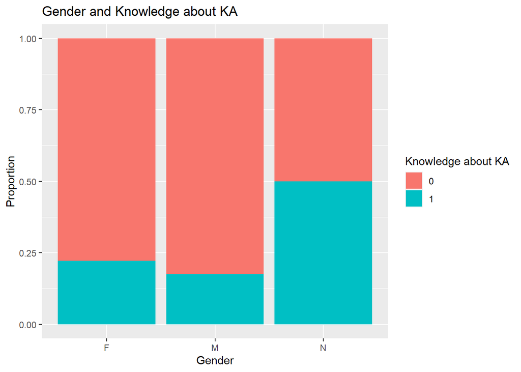

```r
ggplot(data, aes(x = GENDER, fill = Overall.knowledge.about.vector)) +
  geom_bar(position = "fill") +
  labs(x = "Gender", y = "Proportion", fill = "Knowledge about KA") +
  ggtitle("Gender and Knowledge about KA")
```

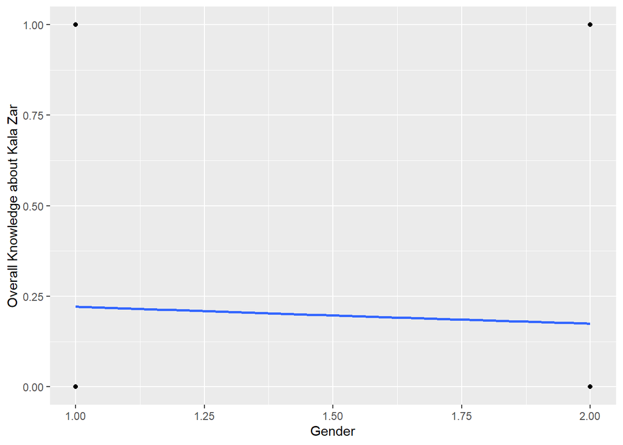

```r
# Read in the data from the CSV file
data <- read.csv("C:\\Users\\sidda\\Downloads\\socio_eco_disease.csv")
data <- subset(data, GENDER != "N")

# Convert the factor variable to numeric
data$GENDER <- as.numeric(factor(data$GENDER))

# Fit a logistic regression model with gender as the predictor and knowledge about Kala Zar as the response
model <- glm(Overall.knowledge.about.vector ~ GENDER, data = data, family = binomial)


# Plot the logistic curve using GGplot
library(ggplot2)

ggplot(data, aes(x = GENDER, y = Overall.knowledge.about.vector)) +
  geom_point() +
  geom_smooth(method = "glm", method.args = list(family = binomial), se = FALSE) +
  xlab("Gender") +
  ylab("Overall Knowledge about Kala Zar")
```

```r
# Load the dataset
data <- read.csv("C:\\Users\\sidda\\Downloads\\socio_eco_disease.csv")

# Select required columns
data_female <- subset(data, select = c("Overall.knowledge.about.KA.disease", "Overall.practice", "GENDER"))

# Filter for female respondents
data_female <- subset(data_female, GENDER == "F")


# Convert variables to factors
data_female$Overall.knowledge.about.KA.disease <- factor(data_female$Overall.knowledge.about.KA.disease)
data_female$Overall.practice <- factor(data_female$Overall.practice)

# Perform chi-square test
model <- chisq.test(data_female$Overall.knowledge.about.KA.disease, data_female$Overall.practice)
# Load the dataset
data <- read.csv("C:\\Users\\sidda\\Downloads\\socio_eco_disease.csv")

# Select required columns
data_male <- subset(data, select = c("Overall.knowledge.about.KA.disease", "Overall.practice", "GENDER"))

# Filter for female respondents
data_male <- subset(data_male, GENDER == "M")


# Convert variables to factors
data_male$Overall.knowledge.about.KA.disease <- factor(data_male$Overall.knowledge.about.KA.disease)
data_male$Overall.practice <- factor(data_male$Overall.practice)

# Perform chi-square test
chisq.test(data_male$Overall.knowledge.about.KA.disease, data_male$Overall.practice)
```

```
##
##  Pearson's Chi-squared test
##
## data:  data_male$Overall.knowledge.about.KA.disease and data_male$Overall.practice
## X-squared = 19.654, df = 3, p-value = 0.0002002
```

```r
data <- read.csv("C:\\Users\\sidda\\Downloads\\socio_eco_disease.csv")

# Select required columns
data_female <- subset(data, select = c("Overall.knowledge.about.KA.disease", "Overall.practice", "GENDER"))

# Filter for female respondents
data_female <- subset(data_female, GENDER == "F")


# Convert variables to factors
data_female$Overall.knowledge.about.KA.disease <- factor(data_female$Overall.knowledge.about.KA.disease)
data_female$Overall.practice <- factor(data_female$Overall.practice)

# Perform chi-square test
chisq.test(data_female$Overall.knowledge.about.KA.disease, data_female$Overall.practice, simulate.p.value=TRUE)
```

```
##
##  Pearson's Chi-squared test with simulated p-value (based on 2000
##  replicates)
##
## data:  data_female$Overall.knowledge.about.KA.disease and data_female$Overall.practice
## X-squared = 11.147, df = NA, p-value = 0.007996
```

```r
# Load the dataset
df <- read.csv("C:\\Users\\sidda\\Downloads\\socio_eco_disease.csv")

# Filter out "N" from GENDER
df <- df[df$GENDER %in% c("F", "M"),]

# Create a contingency table
table <- table(df$GENDER, df$Overall.practice)
table
```

```
##
##       0   1   2   3
##   F   8  41 226  72
##   M   6  47 223  84
```

```r
chisq.test(table)
```

```
##
##  Pearson's Chi-squared test
##
## data:  table
## X-squared = 1.3994, df = 3, p-value = 0.7057
```

```r
# Load the required library
library(tidyverse)
# Read the data
data <- read.csv("C:\\Users\\sidda\\Downloads\\socio_eco_disease.csv")

# Create a subset of the data with the relevant variables
subset <- data %>% select(GENDER, EDUCATION, OCCUPATION,
                          `MONTHLY.FAMILY.INCOME`, `TYPE.OF.HOUSE`,
                          `FAMILY.SIZE`, `NO.OF.BED.ROOMS`, `Overall.attitude`)


subset$`FAMILY.SIZE`[subset$`FAMILY.SIZE` == "MORE"] <- 15
subset$`FAMILY.SIZE` <- as.numeric(subset$`FAMILY.SIZE`)
subset$GENDER <- as.factor(subset$GENDER)
subset$EDUCATION <- as.factor(subset$EDUCATION)
subset$OCCUPATION <- as.factor(subset$OCCUPATION)
subset$`MONTHLY.FAMILY.INCOME` <- as.factor(subset$`MONTHLY.FAMILY.INCOME`)
subset$`TYPE.OF.HOUSE` <- as.factor(subset$`TYPE.OF.HOUSE`)
subset$`NO.OF.BED.ROOMS` <- as.numeric(subset$`NO.OF.BED.ROOMS`)
subset$`Overall.attitude` <- as.factor(subset$`Overall.attitude`)

# Split the data into training and testing sets
set.seed(123)
trainIndex <- sample(1:nrow(subset), 1.0*nrow(subset))
train <- subset[trainIndex, ]
test <- subset[-trainIndex, ]

# Train a logistic regression model
model <- glm(`Overall.attitude` ~ GENDER + EDUCATION + OCCUPATION + `MONTHLY.FAMILY.INCOME` +
               `TYPE.OF.HOUSE` + `FAMILY.SIZE` + `NO.OF.BED.ROOMS`,
             data = train, family = binomial(link="logit"))
summary(model, test = "Chisq")
```

```
##
## Call:
## glm(formula = Overall.attitude ~ GENDER + EDUCATION + OCCUPATION +
##     MONTHLY.FAMILY.INCOME + TYPE.OF.HOUSE + FAMILY.SIZE + NO.OF.BED.ROOMS,
##     family = binomial(link = "logit"), data = train)
##
## Deviance Residuals:
##      Min        1Q    Median        3Q       Max
## -3.02893   0.05333   0.08636   0.14307   0.57735
##
## Coefficients:
##                          Estimate Std. Error z value Pr(>|z|)
## (Intercept)               25.2981 29232.4384   0.001    0.999
## GENDERM                    0.2803     0.8050   0.348    0.728
## GENDERN                   17.2117 18885.7388   0.001    0.999
## EDUCATION1                -1.8223     1.1248  -1.620    0.105
## EDUCATION2                -0.1489     1.4467  -0.103    0.918
## EDUCATION3                15.5639  5041.2899   0.003    0.998
## OCCUPATION1              -17.9685 29232.4383  -0.001    1.000
## OCCUPATION2               -1.3120 30786.9530   0.000    1.000
## OCCUPATION3               -0.9044 29422.5254   0.000    1.000
## OCCUPATION4               -2.1097 34713.3256   0.000    1.000
## MONTHLY.FAMILY.INCOME1     0.8880     0.8025   1.107    0.268
## TYPE.OF.HOUSE2            16.2047  3994.3642   0.004    0.997
## FAMILY.SIZE               -0.1555     0.1504  -1.034    0.301
## NO.OF.BED.ROOMS           -0.6606     0.5415  -1.220    0.222
##
## (Dispersion parameter for binomial family taken to be 1)
##
##     Null deviance: 78.582  on 708  degrees of freedom
## Residual deviance: 66.602  on 695  degrees of freedom
## AIC: 94.602
##
## Number of Fisher Scoring iterations: 20
```

```r
# Load stargazer package
library(stargazer)

# Show model summary as plain text
summary_text <- capture.output(stargazer(model, header = FALSE, type = "text"))
cat(summary_text, sep = "\n")
```

```
##
## ==================================================
##                            Dependent variable:
##                        ---------------------------
##                             Overall.attitude
## --------------------------------------------------
## GENDERM                           0.280
##                                  (0.805)
##
## GENDERN                          17.212
##                               (18,885.740)
##
## EDUCATION1                       -1.822
##                                  (1.125)
##
## EDUCATION2                       -0.149
##                                  (1.447)
##
## EDUCATION3                       15.564
##                                (5,041.290)
##
## OCCUPATION1                      -17.969
##                               (29,232.440)
##
## OCCUPATION2                      -1.312
##                               (30,786.950)
##
## OCCUPATION3                      -0.904
##                               (29,422.530)
##
## OCCUPATION4                      -2.110
##                               (34,713.330)
##
## MONTHLY.FAMILY.INCOME1            0.888
##                                  (0.802)
##
## TYPE.OF.HOUSE2                   16.205
##                                (3,994.364)
##
## FAMILY.SIZE                      -0.156
##                                  (0.150)
##
## NO.OF.BED.ROOMS                  -0.661
##                                  (0.541)
##
## Constant                         25.298
##                               (29,232.440)
##
## --------------------------------------------------
## Observations                       709
## Log Likelihood                   -33.301
## Akaike Inf. Crit.                94.602
## ==================================================
## Note:                  *p<0.1; **p<0.05; ***p<0.01
```

```r
library(car)
# Type II ANOVA test
Anova(model, type="II")
```

```
## Analysis of Deviance Table (Type II tests)
##
## Response: Overall.attitude
##                       LR Chisq Df Pr(>Chisq)
## GENDER                  0.1711  2     0.9180
## EDUCATION               5.1892  3     0.1585
## OCCUPATION              1.6548  4     0.7989
## MONTHLY.FAMILY.INCOME   1.1491  1     0.2837
## TYPE.OF.HOUSE           0.4834  1     0.4869
## FAMILY.SIZE             0.9288  1     0.3352
## NO.OF.BED.ROOMS         1.3877  1     0.2388
```